# Exploring product and sales data for cereal brands and products

Christopher Lacrampe

February 21, 2018

#### Code Header and Libraries in codes below

```r
# Course: BUAN 3210
# Title: Technical Appendix for Midterm Project
# Purpose: Provide EDA to compose a memo
# Date: February 1, 2018
# Author: Christopher Lacrampe
```

```r
#####----- INSTALL THE PACKAGES BELOW BEORE TRYING TO RUN THIS FILE -----#####

rm(list=ls(all=TRUE)) # clears working environment

# The tidyverse package contains ggplot2, tibble, tidyr, readr, purr, and dplyr and several others
library(tidyverse)

# The gridExtra package contains grid.arrange function used to combine plots
library(gridExtra)

# The knitr package contains kable fucntions for formating table
library(knitr)

# ALlows us to construct confidence interval
library(MultinomialCI)

# Allows us to output regression
library(stargazer)
```

#### Load data and begin new EDA

Work with `mtp_sales_data` and `mtp_product_data` data sets

```r
# Load data
salesDat <- read.csv("mtp_sales_data.csv")
productDat <- read.csv("mtp_product_data.csv")

# Structure of data so know what working with
str(salesDat)
```

```
## 'data.frame':    21850 obs. of  7 variables:
##  $ UPC    : Factor w/ 114 levels "00.01.16000.11653",..: 1 1 1 2 2 2 3 3 3 3 ...
##  $ iri_key: int  644347 248741 535806 675634 205272 248741 932600 278738 660222 644937 ...
##  $ week   : int  6 5 11 11 13 14 39 35 45 5 ...
##  $ units  : int  5 2 3 2 8 5 6 1 4 14 ...
##  $ price  : num  0.5 0.5 0.5 0.5 0.5 0.5 1.09 1.59 1.59 1 ...
##  $ promo  : int  0 0 0 0 0 0 0 0 0 0 ...
##  $ ad     : Factor w/ 3 levels "A","B","NONE": 1 3 3 3 3 3 3 3 3 3 ...
```

```r
str(productDat)
```

```
## 'data.frame':    114 obs. of  4 variables:
##  $ UPC   : Factor w/ 114 levels "00-01-16000-11653",..: 1 2 3 4 5 6 7 8 9 10 ...
##  $ brand : Factor w/ 15 levels "GENERAL MILLS CHEERIOS",..: 2 1 2 5 1 3 2 5 2 5 ...
##  $ flavor: Factor w/ 5 levels "CINNAMON TOAST",..: 1 5 1 5 5 2 1 5 1 5 ...
##  $ volume: num  0.06 0.04 0.12 0.11 0.08 0.89 0.98 0.87 0.8 1.5 ...
```

#### Cleaning, merging, and adding variables to the data

```r
# Re-structure upc key in productDat to enable joining
productDat$UPC <- gsub("-", ".", productDat$UPC)

# Seperating brand by company
productDat$company <- fct_collapse(productDat$brand,
             General_Mills = c("GENERAL MILLS CHEERIOS", "GENERAL MILLS CINNAMON TST CR", "GENERAL MILLS COCOA PUFFS", "GENERAL MILLS KIX", "GENERAL MILLS LUCKY CHARMS"),
             Kelloggs = c("KELLOGGS COCOA KRISPIES", "KELLOGGS FROOT LOOPS", "KELLOGGS FROSTED FLAKES", "KELLOGGS FROSTED MINI WHEATS", "KELLOGGS RAISIN BRAN", "KELLOGGS RICE KRISPIES", "KELLOGGS SMART START", "KELLOGGS SPECIAL K"),
             Post = c("POST GRAPE NUTS", "POST SHREDDED WHEAT")
                               )

# Create revenue and price per volume variables for greater understanding
salesDat$revenue <- salesDat$price * salesDat$units
salesDat$price_per_volume <- salesDat$price /productDat$volume

# Mutating "promo" variable into factor levels of no and yes for inStorePromotions
salesDat$promo <- factor(salesDat$promo)

# Combining the two datasets into a new total dataset
totalDat <- salesDat %>%
    left_join(productDat, by = "UPC")
```

Having restructured the UPC keys so they match in both the mtp_sales_data and mtp_product_data, we can now join both for a broader range of variable comparisons.

### 1. Exploring non-graphical relationships with emphasis on categorical variables

```r
kable(
  salesDat %>%
    left_join(productDat, by = "UPC") %>%
    select(brand, flavor, volume, units, price, promo, ad, revenue, price_per_volume) %>%
    group_by(brand) %>%
    summarise(count = n(),
    percent = (sum(count) / nrow(salesDat)) * 100,
    mean_revenue = mean(revenue),
    mean_price_vol = mean(price_per_volume),
    mean_units = mean(units))
)
```

| brand | count | percent | mean_revenue | mean_price_vol | mean_units |
| --- | --- | --- | --- | --- | --- |
| GENERAL MILLS CHEERIOS | 1458 | 6.672769 | 51.19142 | 9.915218 | 14.012346 |
| GENERAL MILLS CINNAMON TST CR | 1834 | 8.393593 | 34.15395 | 10.901157 | 8.743184 |
| GENERAL MILLS COCOA PUFFS | 1020 | 4.668192 | 25.74243 | 9.758667 | 7.983333 |
| GENERAL MILLS KIX | 1196 | 5.473684 | 26.98423 | 9.823863 | 7.591973 |
| GENERAL MILLS LUCKY CHARMS | 1681 | 7.693364 | 36.21869 | 11.379371 | 9.118977 |
| KELLOGGS COCOA KRISPIES | 881 | 4.032037 | 16.96889 | 8.998650 | 5.196368 |
| KELLOGGS FROOT LOOPS | 2192 | 10.032037 | 20.62031 | 9.659594 | 6.351734 |
| KELLOGGS FROSTED FLAKES | 2295 | 10.503433 | 33.35530 | 10.220661 | 9.461002 |
| KELLOGGS FROSTED MINI WHEATS | 1574 | 7.203661 | 35.14232 | 10.213239 | 9.581321 |
| KELLOGGS RAISIN BRAN | 1266 | 5.794050 | 37.01339 | 10.157151 | 10.184834 |
| KELLOGGS RICE KRISPIES | 1450 | 6.636156 | 35.00250 | 9.808787 | 9.949655 |
| KELLOGGS SMART START | 1134 | 5.189931 | 22.71065 | 10.565803 | 6.295414 |
| KELLOGGS SPECIAL K | 1391 | 6.366133 | 35.36902 | 10.787352 | 9.171100 |
| POST GRAPE NUTS | 1289 | 5.899313 | 26.03881 | 10.299845 | 7.072149 |
| POST SHREDDED WHEAT | 1189 | 5.441648 | 19.16284 | 9.598455 | 5.723297 |

From this table, we can see that Kelloggs froot loops and frosted flakes comprise a greater proportion of the cereal data relative to the other brands’ products. However, we can see that General Mills’ cheerios has the highest average revenue which is coupled with a midling price_per_volume.

```r
kable(
  salesDat %>%
    left_join(productDat, by = "UPC") %>%
    select(company, brand, flavor, volume, units, price, promo, ad, revenue, price_per_volume) %>%
    group_by(company) %>%
    summarise(count = n(),
    percent = (sum(count) / nrow(salesDat)) * 100,
    mean_revenue = mean(revenue),
    mean_price_vol = mean(price_per_volume),
    mean_units = mean(units))
)
```

| company | count | percent | mean_revenue | mean_price_vol | mean_units |
| --- | --- | --- | --- | --- | --- |
| General_Mills | 7189 | 32.90160 | 35.70587 | 10.471695 | 9.600362 |
| Kelloggs | 12183 | 55.75744 | 29.92518 | 10.071593 | 8.414348 |
| Post | 2478 | 11.34096 | 22.73956 | 9.963302 | 6.424939 |

From this graphic, we can see that the majority of observations include products owned by Kelloggs, however the mean revenue per observation is the largest for General Mills.

```r
kable(
  salesDat %>%
    left_join(productDat, by = "UPC") %>%
    select(brand, flavor, volume, units, price, promo, ad, revenue, price_per_volume) %>%
    group_by(flavor) %>%
    summarise(count = n(),
    percent = (sum(count) / nrow(salesDat)) * 100,
    mean_revenue = mean(revenue),
    mean_price_vol = mean(price_per_volume),
    mean_units = mean(units))
)
```

| flavor | count | percent | mean_revenue | mean_price_vol | mean_units |
| --- | --- | --- | --- | --- | --- |
| CINNAMON TOAST | 1834 | 8.393593 | 34.15395 | 10.901157 | 8.743184 |
| COCOA | 1901 | 8.700229 | 21.67642 | 9.406444 | 6.691741 |
| FRUIT | 2192 | 10.032037 | 20.62031 | 9.659594 | 6.351734 |
| REGULAR | 8816 | 40.347826 | 30.34609 | 10.078082 | 8.479583 |
| TOASTED | 7107 | 32.526316 | 36.73006 | 10.521418 | 9.851555 |

This table informs us that Cinnamon Toast and Toasted flavored cereal have the highest average revenue when comparing other flavors. Note that while cinnamon toast and toasted have similairly high average revenues, toasted cereals have a much higher proportion at 32%, relative to the smaller proportion of cinnamon toast.

```r
kable(
  salesDat %>%
    left_join(productDat, by = "UPC") %>%
    select(brand, flavor, volume, units, price, promo, ad, revenue, price_per_volume) %>%
    group_by(ad, promo) %>%
    summarise(count = n(),
    percent = (sum(count) / nrow(salesDat)) * 100,
    mean_revenue = mean(revenue),
    mean_price_vol = mean(price_per_volume),
    mean_units = mean(units))
)
```

| ad | promo | count | percent | mean_revenue | mean_price_vol | mean_units |
| --- | --- | --- | --- | --- | --- | --- |
| A | 0 | 683 | 3.125858 | 31.93887 | 11.290284 | 8.304539 |
| A | 1 | 773 | 3.537757 | 34.18875 | 7.835433 | 12.849935 |
| B | 0 | 402 | 1.839817 | 31.25866 | 9.357757 | 8.587065 |
| B | 1 | 659 | 3.016018 | 35.11992 | 7.121297 | 12.904401 |
| NONE | 0 | 16220 | 74.233410 | 30.54813 | 10.744166 | 7.856782 |
| NONE | 1 | 3113 | 14.247140 | 31.53670 | 8.409608 | 10.424671 |

From this table, we can see that the presence of in-store promotions is linked to higher average revenue relative to observations where in-store promotions are not ongoing. However, without an in-store promotion ongoing, most of the average revenues are similair regardless of ad-campaing type/presence.

### 2. Exploring numerical relationships (e.g. units by price)

```r
cor(salesDat$price_per_volume, salesDat$units)
```

```
## [1] -0.0306361
```

```r
cor(salesDat$revenue, salesDat$units)
```

```
## [1] 0.9061386
```

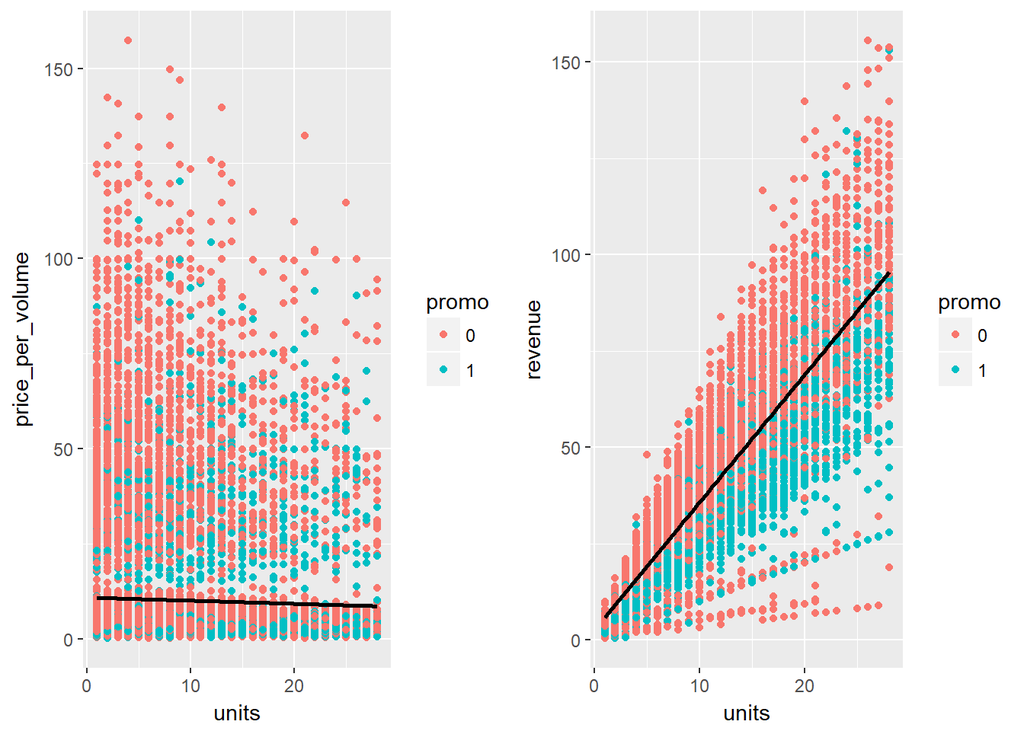

```r
grid.arrange(
ggplot(salesDat, aes(x = units, y = price_per_volume, color = promo)) +
  geom_point() +
  geom_smooth(method = "lm", se = TRUE, color = "black"),
ggplot(salesDat, aes(x = units, y = revenue, color = promo)) +
  geom_point() +
  geom_smooth(method = "lm", se = TRUE, color = "black"),
ncol = 2
)
```

From these two graphics we can see a dstinct positive trend between units and revenue, along with noting that promotions tend to lead to lower revenue sales (likely because the goods are discounted during promotions). However, in regards to price and volume, there appears to be a very minimal negative relationship, likely due to the fact that as the price per volume falls, buyers tend to purchase more.

```r
cor(salesDat$price_per_volume, salesDat$revenue)
```

```
## [1] 0.02068909
```

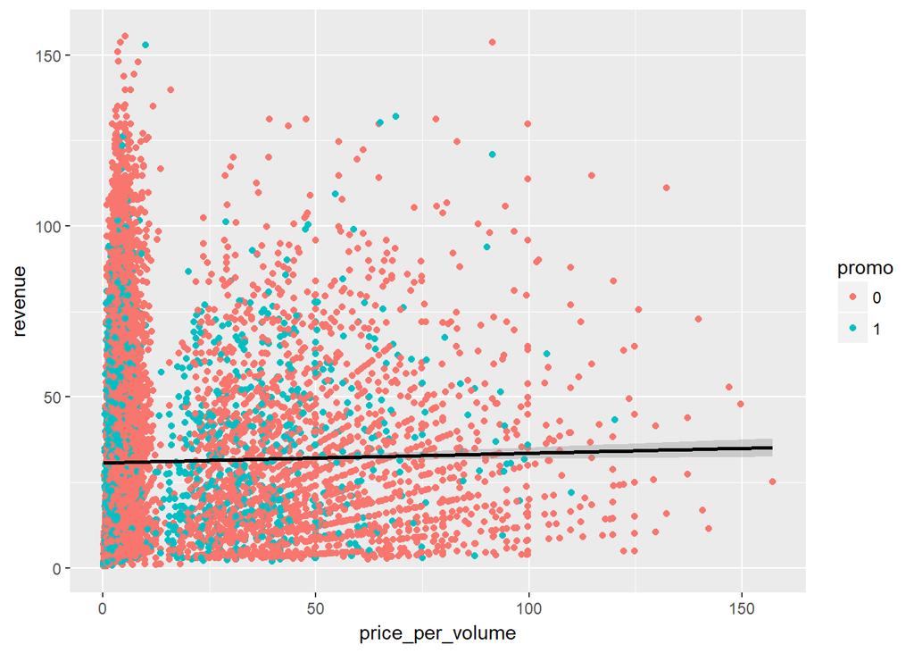

```r
ggplot(salesDat, aes(x = price_per_volume, y = revenue, color = promo)) +
  geom_point() +
  geom_smooth(method = "lm", se = TRUE, color = "black")
```

Although some interesting radial patterns appear from the origin, the regression line indicates that there is not a strong relationship between price per volume and revenue.

```r
cor(salesDat$price, salesDat$units)
```

```
## [1] -0.1907078
```

```r
cor(salesDat$price, salesDat$revenue)
```

```
## [1] 0.1527556
```

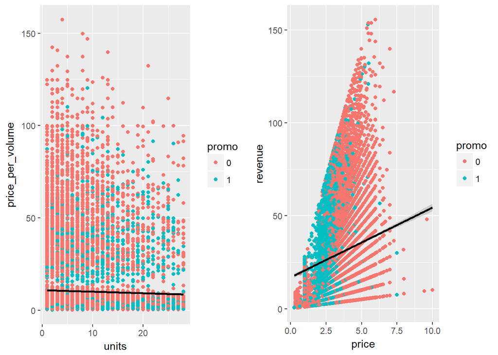

```r
grid.arrange(

ggplot(salesDat, aes(x = units, y = price_per_volume, color = promo)) +
  geom_point() +
  geom_smooth(method = "lm", se = TRUE, color = "black"),

  ggplot(salesDat, aes(x = price, y = revenue, color = promo)) +
  geom_point() +
  geom_smooth(method = "lm", se = TRUE, color = "black"),

  ncol = 2
)
```

By removing the effects of normalizing price by unit volume, we can see that the effects of the variable’s relationships with units and revenue grows stronger.

#### Let’s ensure statistical differences by performing t-tests

```r
t.test(salesDat$price_per_volume[salesDat$price])
```

```
##
##  One Sample t-test
##
## data:  salesDat$price_per_volume[salesDat$price]
## t = 284.84, df = 21685, p-value < 2.2e-16
## alternative hypothesis: true mean is not equal to 0
## 95 percent confidence interval:
##  5.757495 5.837281
## sample estimates:
## mean of x
##  5.797388
```

```r
t.test(salesDat$price_per_volume[salesDat$units])
```

```
##
##  One Sample t-test
##
## data:  salesDat$price_per_volume[salesDat$units]
## t = 160.85, df = 21849, p-value < 2.2e-16
## alternative hypothesis: true mean is not equal to 0
## 95 percent confidence interval:
##  3.867042 3.962450
## sample estimates:
## mean of x
##  3.914746
```

```r
t.test(salesDat$price_per_volume[salesDat$revenue])
```

```
##
##  One Sample t-test
##
## data:  salesDat$price_per_volume[salesDat$revenue]
## t = 97.175, df = 21831, p-value < 2.2e-16
## alternative hypothesis: true mean is not equal to 0
## 95 percent confidence interval:
##  2.748655 2.861821
## sample estimates:
## mean of x
##  2.805238
```

```r
t.test(salesDat$revenue[salesDat$units])
```

```
##
##  One Sample t-test
##
## data:  salesDat$revenue[salesDat$units]
## t = 139.32, df = 21849, p-value < 2.2e-16
## alternative hypothesis: true mean is not equal to 0
## 95 percent confidence interval:
##  5.808668 5.974441
## sample estimates:
## mean of x
##  5.891555
```

### 3. Exploring ad categories by various densities

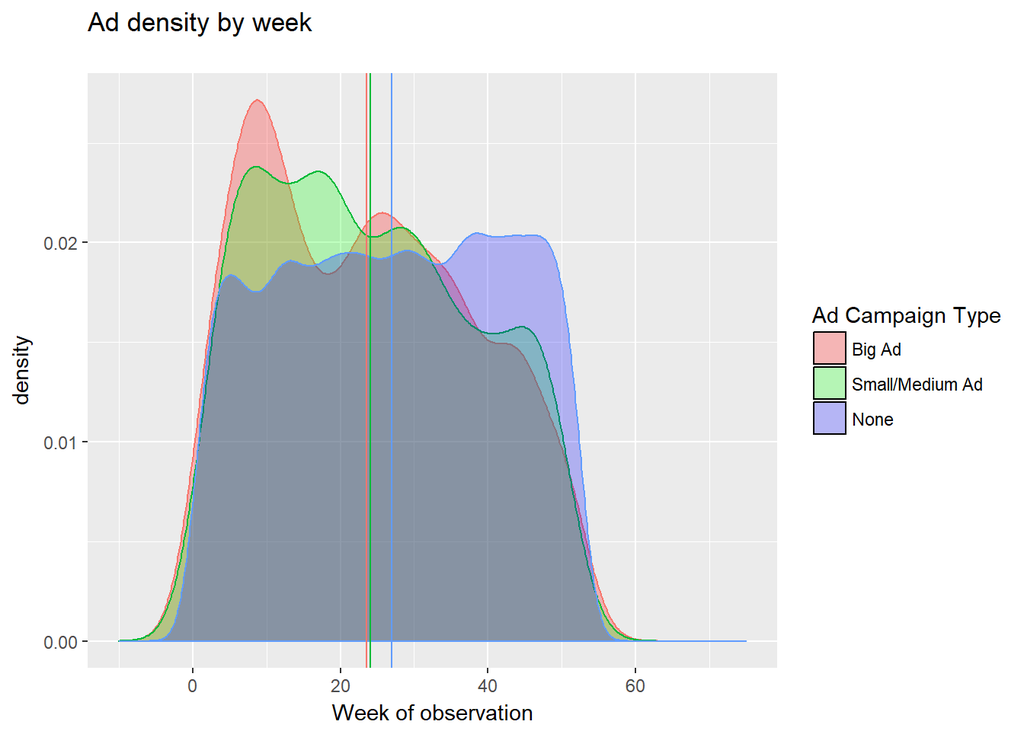

```r
# First calculate the mean
week_mean <- salesDat %>%
  group_by(ad) %>%
  summarise(week_mean = mean(week))

# Use geom_density to illustrate PDF
salesDat %>%
  ggplot(aes(x = week, fill = ad, color = ad)) +
  guides(color = FALSE) +
  labs(title = "Ad density by week\n", x = "Week of observation", fill = "Ad Campaign Type") +
  scale_fill_manual(labels = c("Big Ad", "Small/Medium Ad", "None"), values = c("red", "green", "blue"))+
  geom_density(alpha = 0.25) +
  geom_vline(data = week_mean, aes(xintercept = week_mean, color = ad)) + # Bring in calculated mean
  xlim(-10, 75) # Had to set bounds to visualize
```

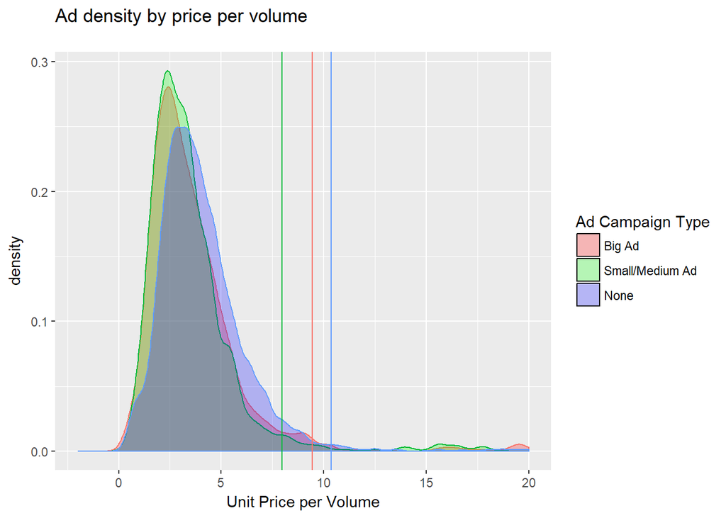

```r
# First calculate the mean
mean_price_per_volume <- salesDat %>%
  group_by(ad) %>%
  summarise(mean_price_per_volume = mean(price_per_volume))

# Use geom_density to illustrate PDF
salesDat %>%
  ggplot(aes(x = price_per_volume, fill = ad, color = ad)) +
  guides(color = FALSE) +
  labs(title = "Ad density by price per volume\n", x = "Unit Price per Volume", fill = "Ad Campaign Type") +
  scale_fill_manual(labels = c("Big Ad", "Small/Medium Ad", "None"), values = c("red", "green", "blue"))+
  geom_density(alpha = 0.25) +
  geom_vline(data = mean_price_per_volume, aes(xintercept = mean_price_per_volume, color = ad)) + # Bring in calculated mean
  xlim(-2, 20) # Had to set bounds to visualize
```

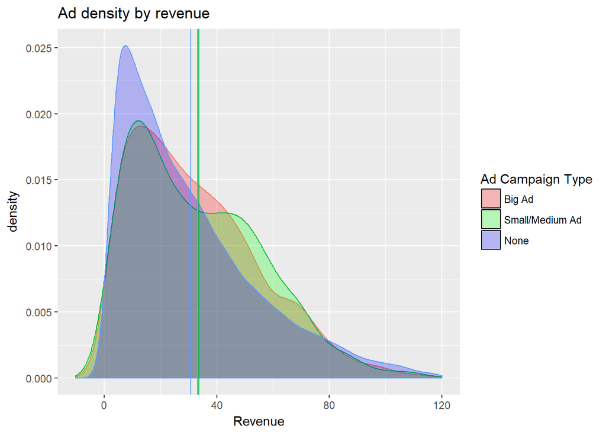

```r
# First calculate the mean
mean_revenue <- salesDat %>%
  group_by(ad) %>%
  summarise(mean_revenue = mean(revenue))

# Use geom_density to illustrate PDF
salesDat %>%
  ggplot(aes(x = revenue, fill = ad, color = ad)) +
  guides(color = FALSE) +
  labs(title = "Ad density by revenue", x = "Revenue", fill = "Ad Campaign Type") +
  scale_fill_manual(labels = c("Big Ad", "Small/Medium Ad", "None"), values = c("red", "green", "blue"))+
  geom_density(alpha = 0.25) +
  geom_vline(data = mean_revenue, aes(xintercept = mean_revenue, color = ad)) + # Bring in calculated mean
  xlim(-10, 120) # Had to set bounds to visualize
```

### 3. Exploring relationships between promotion and ad types

```r
# Creating confidence interval tab
R_C_n <- salesDat %>%
  group_by(ad, promo) %>%
  summarise(n = n())

# Calulate confidence intervals using mulitnomialCI
R_C_n_ci <- multinomialCI(t(R_C_n[, 3]), 0.05) # Have to use t() to transpose the count table
                                           # alpha = 0.05 indicates 95% confidence level

# Next create a table with proportions that is ggplot friendly
R_C_tab <- salesDat %>%
  group_by(ad, promo) %>%
  summarise(p = n()/sum(nrow(salesDat)))

# Add the confindence inervals to the table of proportions
R_C_tab$ci_l <- R_C_n_ci[,1]
R_C_tab$ci_u <- R_C_n_ci[,2]

# Show the table
(R_C_tab)
```

```
## # A tibble: 6 x 5
## # Groups: ad [?]
##   ad     promo       p   ci_l   ci_u
##   <fctr> <fctr>  <dbl>  <dbl>  <dbl>
## 1 A      0      0.0313 0.0256 0.0370
## 2 A      1      0.0354 0.0297 0.0411
## 3 B      0      0.0184 0.0127 0.0241
## 4 B      1      0.0302 0.0245 0.0359
## 5 NONE   0      0.742  0.737  0.748
## 6 NONE   1      0.142  0.137  0.148
```

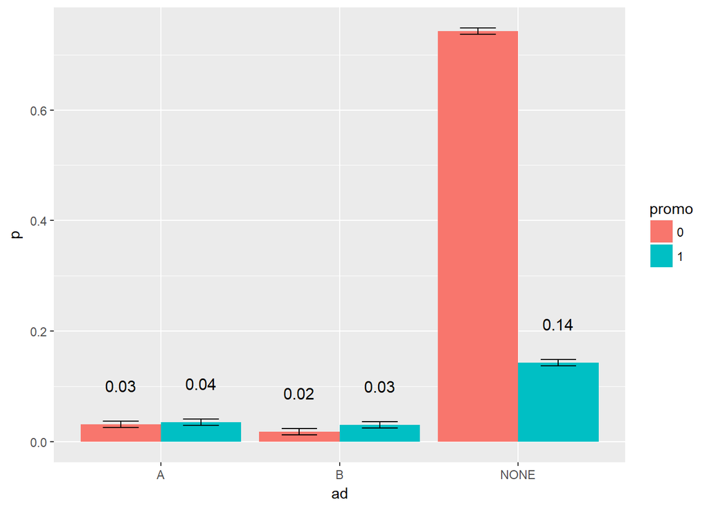

```r
R_C_tab %>%
  ggplot(aes(x = ad, y = p, fill = promo)) +
  geom_bar(stat="identity", position = "dodge") +
  geom_text(aes(label = round(p, 2)), vjust=-2.7, color = "black", # vjust moves lables above CI
            position = position_dodge(0.9), size = 4) +
  geom_errorbar(aes(ymin = ci_l, ymax = ci_u),
                width = 0.4, position = position_dodge(0.9))
```

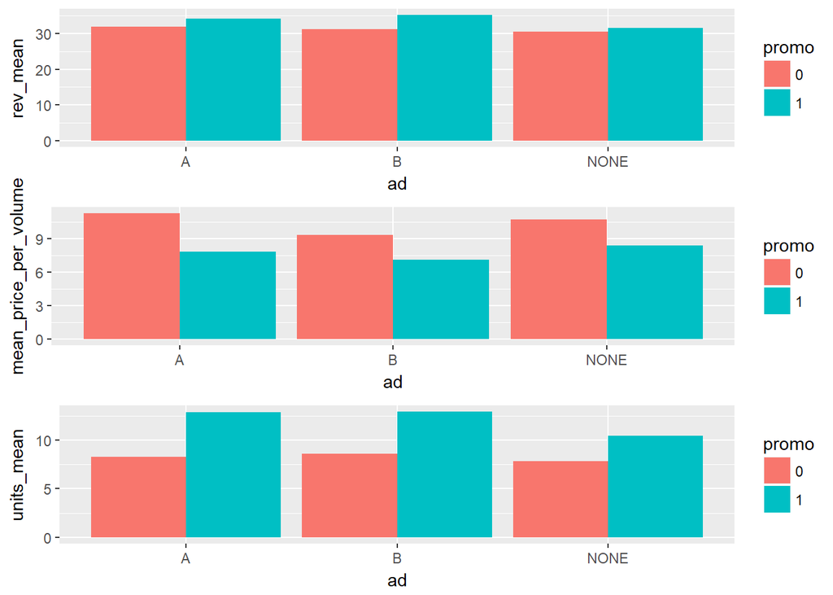

```r
grid.arrange(
salesDat %>%
  group_by(promo, ad) %>%
  summarise(rev_mean = mean(revenue)) %>%
  ggplot(salesDat, mapping = aes(x = ad, y = rev_mean, fill = promo)) +
    geom_bar(stat="identity", position = "dodge"),

salesDat %>%
  group_by(promo, ad) %>%
  summarise(mean_price_per_volume = mean(price_per_volume)) %>%
  ggplot(salesDat, mapping = aes(x = ad, y = mean_price_per_volume, fill = promo)) +
    geom_bar(stat="identity", position = "dodge"),

salesDat %>%
  group_by(promo, ad) %>%
  summarise(units_mean = mean(units)) %>%
  ggplot(salesDat, mapping = aes(x = ad, y = units_mean, fill = promo)) +
    geom_bar(stat="identity", position = "dodge"),

ncol = 1
)
```

Let’s explore a multivariate regression of price_per_revenue by variables from totalDat

```r
pricemod <- lm(price_per_volume~week+units+promo+ad, data = salesDat)
unitsmod <- lm(units~week+price_per_volume+promo+ad, data = salesDat)
revmod <- lm(revenue~week+revenue+promo+ad+company, data = totalDat)
stargazer(pricemod, unitsmod, revmod, type = "html")
```

|  | *Dependent variable:* |  |  |
| --- | --- | --- | --- |
|  | price_per_volume | units | revenue |
|  | (1) | (2) | (3) |
| week | 0.008 | -0.012*** | -0.029*** |
|  | (0.008) | (0.003) | (0.011) |
| units | -0.050*** |  |  |
|  | (0.018) |  |  |
| price_per_volume |  | -0.007*** |  |
|  |  | (0.002) |  |
| promo1 | -2.308*** | 2.912*** | 1.783*** |
|  | (0.320) | (0.115) | (0.426) |
| adB | -1.256* | 0.284 | 0.953 |
|  | (0.723) | (0.265) | (0.977) |
| adNONE | -0.093 | -1.324*** | -1.568** |
|  | (0.501) | (0.183) | (0.678) |
| companyKelloggs |  |  | -5.898*** |
|  |  |  | (0.361) |
| companyPost |  |  | -13.060*** |
|  |  |  | (0.564) |
| Constant | 11.022*** | 9.513*** | 37.518*** |
|  | (0.561) | (0.197) | (0.756) |
| Observations | 21,850 | 21,850 | 21,850 |
| R<sup>2</sup> | 0.004 | 0.046 | 0.028 |
| Adjusted R<sup>2</sup> | 0.004 | 0.045 | 0.028 |
| Residual Std. Error | 17.888 (df = 21844) | 6.548 (df = 21844) | 24.190 (df = 21843) |
| F Statistic | 17.993*** (df = 5; 21844) | 208.821*** (df = 5; 21844) | 106.682*** (df = 6; 21843) |
| *Note:* | p<0.1; p<0.05; p<0.01 |  |  |

### 4. Exploring company levels by densities

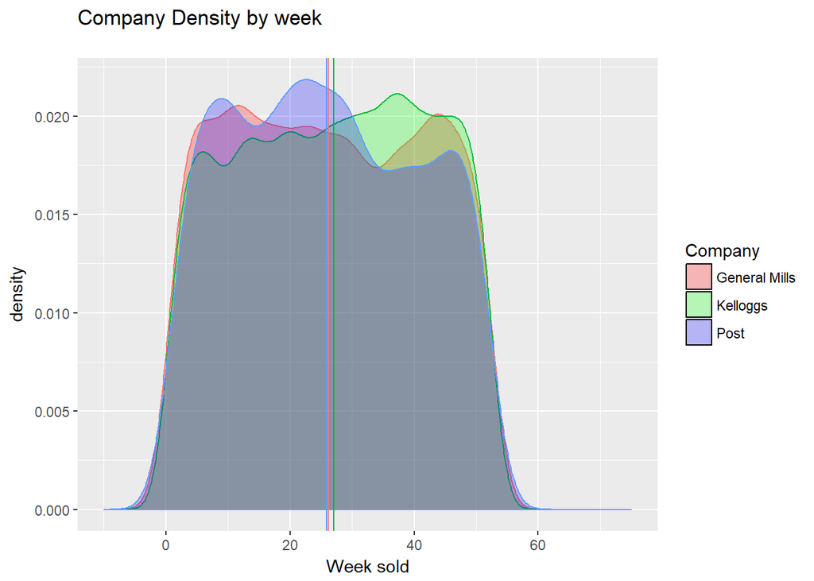

```r
mean_week <- totalDat %>%
  group_by(company) %>%
  summarise(mean_week = mean(week))

# Use geom_density to illustrate PDF
totalDat %>%
  ggplot(aes(x = week, fill = company, color = company)) +
  guides(color = FALSE) +
  labs(title = "Company Density by week\n", x = "Week sold", fill = "Company") +
  scale_fill_manual(labels = c("General Mills", "Kelloggs", "Post"), values = c("red", "green", "blue"))+
  geom_density(alpha = 0.25) +
  geom_vline(data = mean_week, aes(xintercept = mean_week, color = company)) + # Bring in calculated mean
  xlim(-10, 75) # Had to set bounds to visualize
```

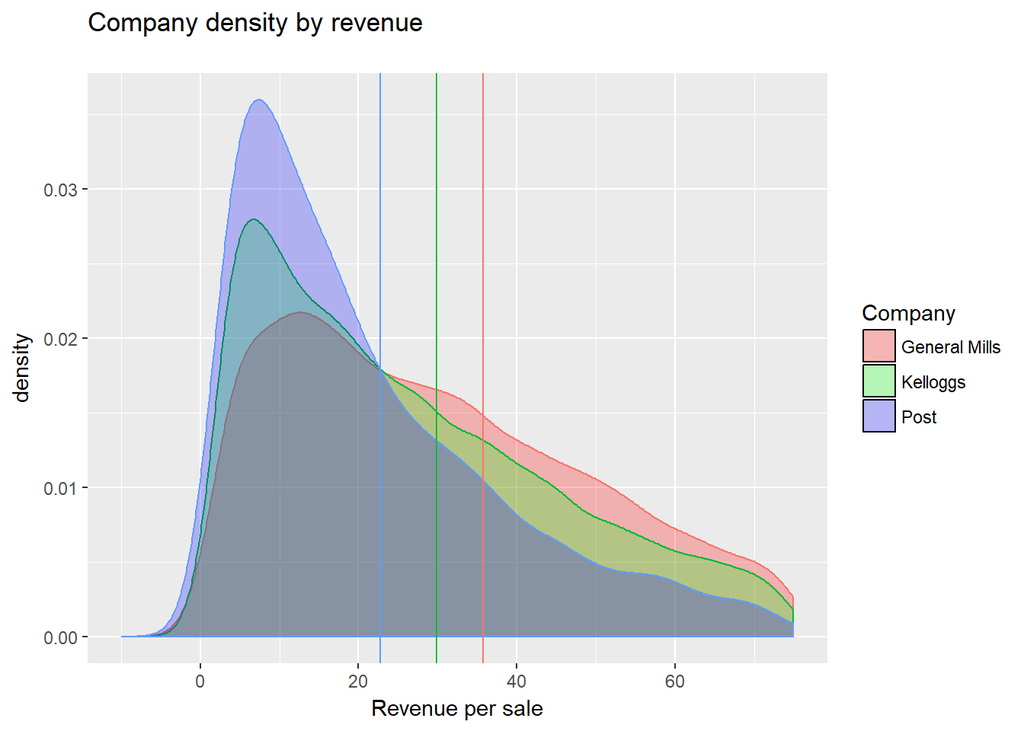

```r
revenue_mean <- totalDat %>%
  group_by(company) %>%
  summarise(revenue_mean = mean(revenue))

# Use geom_density to illustrate PDF
totalDat %>%
  ggplot(aes(x = revenue, fill = company, color = company)) +
  guides(color = FALSE) +
  labs(title = "Company density by revenue\n", x = "Revenue per sale", fill = "Company") +
  scale_fill_manual(labels = c("General Mills", "Kelloggs", "Post"), values = c("red", "green", "blue"))+
  geom_density(alpha = 0.25) +
  geom_vline(data = revenue_mean, aes(xintercept = revenue_mean, color = company)) + # Bring in calculated mean
  xlim(-10, 75) # Had to set bounds to visualize
```

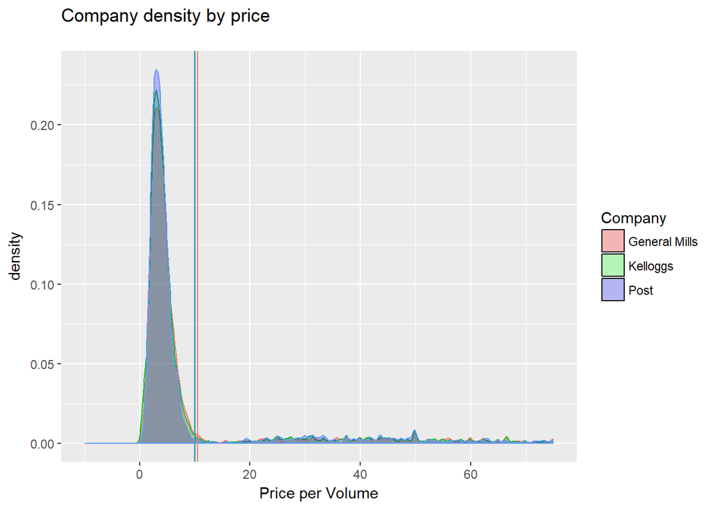

```r
price_per_volume_mean <- totalDat %>%
  group_by(company) %>%
  summarise(price_per_volume_mean = mean(price_per_volume))

# Use geom_density to illustrate PDF
totalDat %>%
  ggplot(aes(x = price_per_volume, fill = company, color = company)) +
  guides(color = FALSE) +
  labs(title = "Company density by price\n", x = "Price per Volume", fill = "Company") +
  scale_fill_manual(labels = c("General Mills", "Kelloggs", "Post"), values = c("red", "green", "blue"))+
  geom_density(alpha = 0.25) +
  geom_vline(data = price_per_volume_mean, aes(xintercept = price_per_volume_mean, color = company)) + # Bring in calculated mean
  xlim(-10, 75) # Had to set bounds to visualize
```

The results from the company density by revenue appear to be the most promising, where sales of General Mills yiels higher average revenue than other companies, let’s dig into this difference a little deeper.

### 5. Exploring company data by ad and promo (rev and units as well)

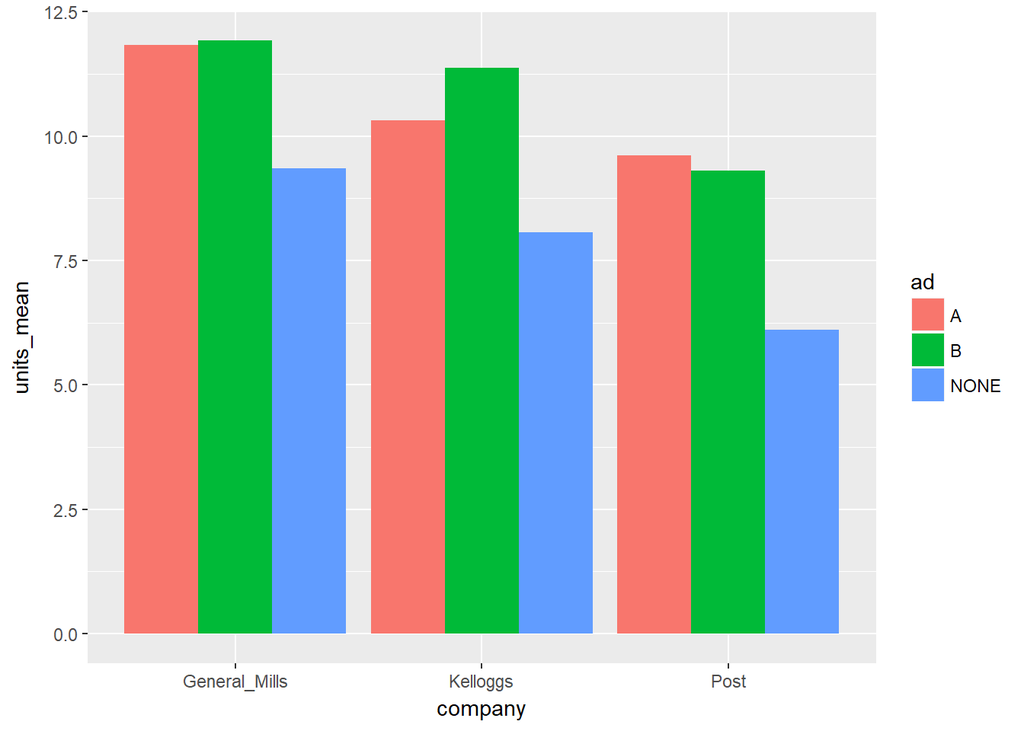

```r
# Exploring bar graphs for units per sale
totalDat %>%
  group_by(company, ad) %>%
  summarise(units_mean = mean(units)) %>%
  ggplot(salesDat, mapping = aes(x = company, y = units_mean, fill = ad)) +
    geom_bar(stat="identity", position = "dodge")
```

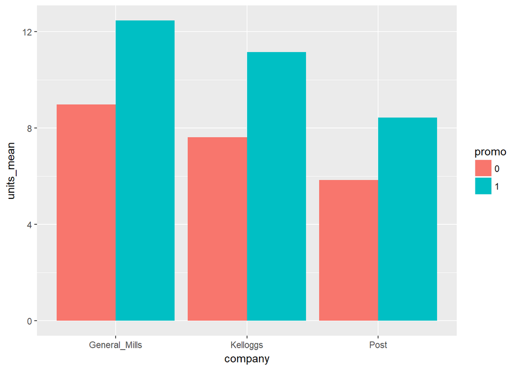

```r
totalDat %>%
  group_by(company, promo) %>%
  summarise(units_mean = mean(units)) %>%
  ggplot(salesDat, mapping = aes(x = company, y = units_mean, fill = promo)) +
    geom_bar(stat="identity", position = "dodge")
```

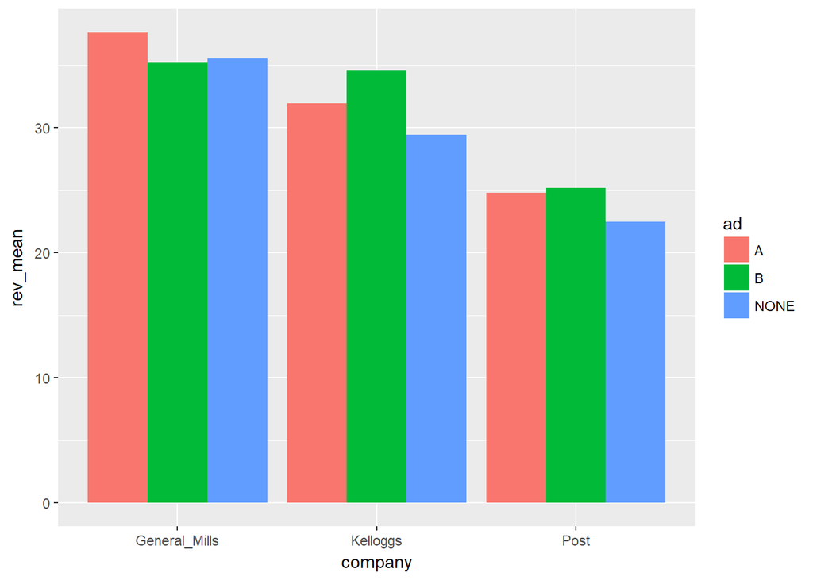

```r
# Exploring bar graphs for revenue per sale
totalDat %>%
  group_by(company, ad) %>%
  summarise(rev_mean = mean(revenue)) %>%
  ggplot(salesDat, mapping = aes(x = company, y = rev_mean, fill = ad)) +
    geom_bar(stat="identity", position = "dodge")
```

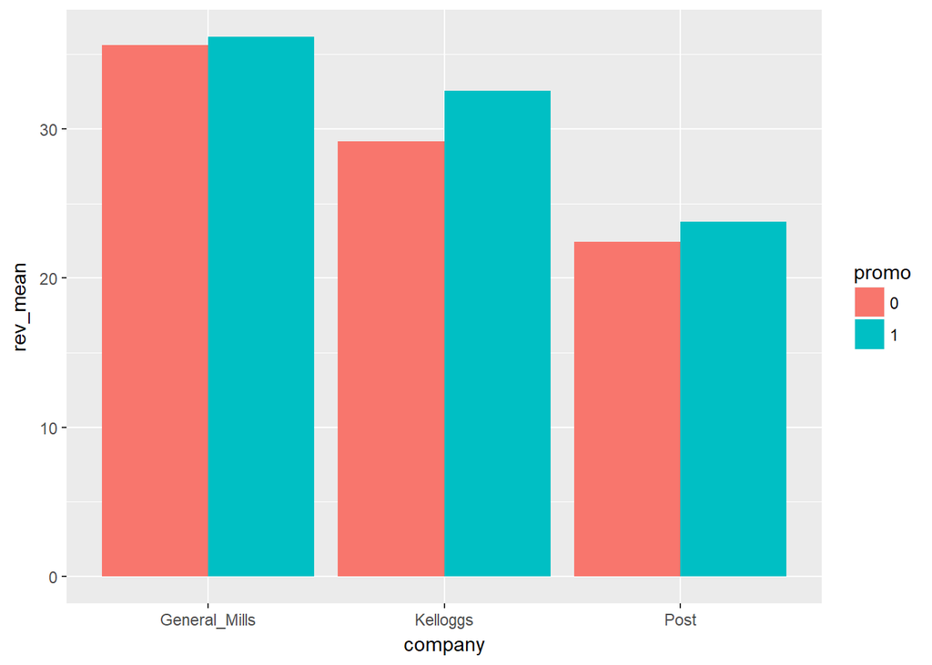

```r
totalDat %>%
  group_by(company, promo) %>%
  summarise(rev_mean = mean(revenue)) %>%
  ggplot(salesDat, mapping = aes(x = company, y = rev_mean, fill = promo)) +
    geom_bar(stat="identity", position = "dodge")
```

From these graphs, we can see that general mills products have a higher average revenue mean relative to the other cereal companies regardless of promotions or ad campaign types. However, General Mills’ small ad campaign types produce fairly similair mean revenue per sale relative to kellogs same campaign types. Let’s check the difference by adding confidence intervals.

#### Repeat bar graph including confidence intervals

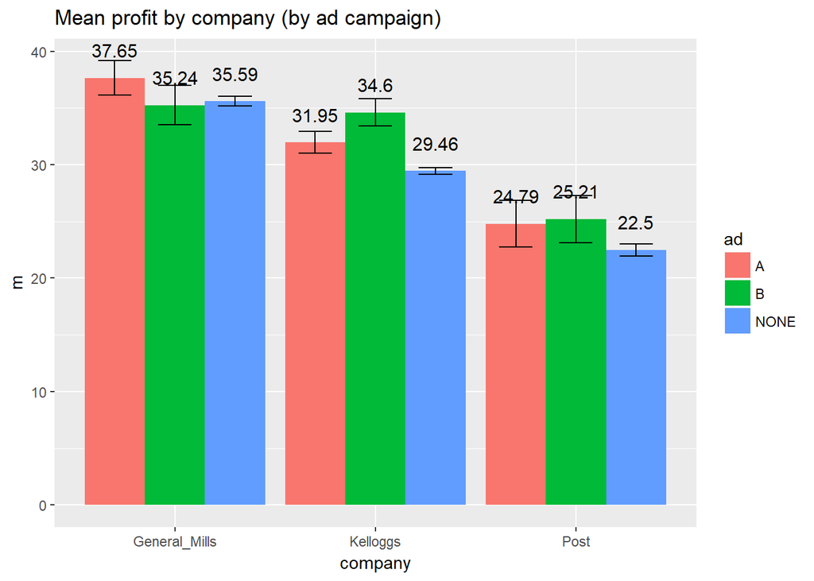

```r
z <- qnorm(.90)

totalDat %>%
  group_by(company, ad) %>%
  summarise(m = mean(revenue), sd = sd(revenue),
            n = n(), ci = z * sd/sqrt(n)) %>%
  ggplot(totalDat, mapping = aes(x = company, y = m, fill = ad)) +
  geom_bar(stat = "identity", position = "dodge") +
  geom_text(aes(label = round(m, 2)), vjust=-1.5, color = "black",
            position = position_dodge(0.9), size = 4) +
  geom_errorbar(aes(ymin = m - ci, ymax = m + ci),
                width = 0.5, position = position_dodge(0.9)) +
  ggtitle("Mean profit by company (by ad campaign) ")
```

By looking at the confidence intervals, we can see that there is no significant difference between running a medium/large ad campaign vs running a small add campaign for General Mills, however, there is a difference between running a medium/large add campaign and running no ad campaign. Furthermore, their isn’t a significant difference between running a small campaign for General Mills vs Kelloggs.

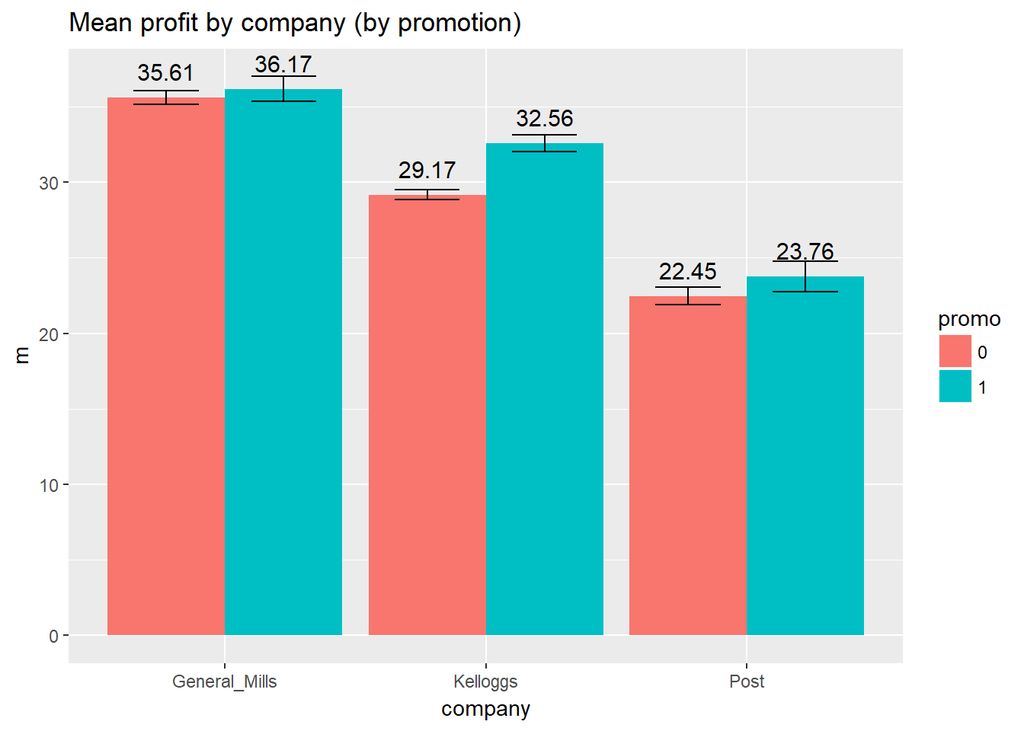

```r
z <- qnorm(0.90)

totalDat %>%
  group_by(company, promo) %>%
  summarise(m = mean(revenue), sd = sd(revenue),
            n = n(), ci = z * sd/sqrt(n)) %>%
  ggplot(aes(x = company, y = m, fill = promo)) +
  geom_bar(stat = "identity", position = "dodge") +
  geom_text(aes(label = round(m, 2)), vjust=-1, color = "black",
            position = position_dodge(0.9), size = 4) +
  geom_errorbar(aes(ymin = m - ci, ymax = m + ci),
                width = 0.5, position = position_dodge(0.9)) +
  ggtitle("Mean profit by company (by promotion) ")
```

```r
save.image("Technical-Appendix.RData")
```